# Statisztika Beadandó 2024

## Szerzők

| Név | Neptun |
| --- | --- |
| Mosonyi Martin | KJCROC |
| Ócsai Máté Zsigmond | COQFUY |

## Feladat leírása

Átfogó statisztikai elemzés készítése, melynek alapja választási eredmények és települési jellemzők vizsgálata, annak összefüggései.

> Általunk választott választás: **Európai parlamenti választás 2019.**

> Általunk válaszott települési jellemzők (2019-es adatok):
1. Állandó népesség; 18-59 évesek (dec. 31.) (fő)
2. 65 év feletti népesség, 100 fő 0-14 éves korú népesség (fő)
3. Általános iskolai végzettségű nyilvántartott álláskeresők (fő)

A statisztikai elemzés kitér:

- adatok betöltése, átalakítása
- adattisztítás, vagyis hiányzó/hibás/nagyon kiugró értékek azonosítása, javítása, ezen lépések dokumentálása
- alapstatisztikák, ezen mutatók értelmezése, grafikai eszközök használata
- konfidenciainterrvallum készítése, értelmezése
- hipotézisek felállítása, feltételezések bemutatása, próbák elvégzése, eredmények értelmezése
- konklúzió, az egész elemezés során kapott értékek áttekintése, érdekes összefüggések kiemelése

## Adatok javítása

Feladataink közé tartozott az adatok javítása.

Elsősorban, a hiányzó adatokat pótoltuk, ilyen volt sok esetben, az *általános iskolai végzettégű nyilvántartott álláskeresők* esetében. Ezekhez mindenhova **%-os** módon helyettesítettünk a kiinduló pont az adott nyilvántarott adat volt (**Aba** alapján):

| Állandó népesség (18-59) évesek | Általános iskolai végzettségű nyilvántartott álláskeresők |
| --- | --- |
| 2832 | 38 |

Azaz: átlagosan 74 emberre (18-59 között) jut 1 olyan álláskereső akinek általános iskolai végzettsége van.

Ahol, ezen adat javításra került:

| Város név | Lakosság (18-59) | Javított álláskeresők száma |
| --- | --- | --- |
| Ábrahámhegy | 277 | 4 |
| Almásháza | 54 | 0 |
| Alsótelekes | 75 | 1 |
| Apácatorna | 82 | 1 |
| Arka | 46 | 0 |
| Árpás | 149 | 2 |
| Baglad | 19 | 0 |
| Bágyogszovát | 749 | 10 |
| Bakonygyirót | 87 | 1 |
| Bakonykúti | 91 | 1 |
| Bakonyság | 33 | 1 |
| Balatonszepezd | 205 | 2 |
| Baskó | 111 | 1 |
| Becskeháza | 18 | 0 |
| Belecska | 227 | 3 |
| Bezenye | 826 | 11 |
| Bodmér | 131 | 1 |
| Bodonhely | 185 | 2 |
| Bodorfa | 63 | 0 |
| Bogyoszló | 353 | 5 |
| Bokor | 60 | 0 |
| Bonyhádvarasd | 256 | 3 |
| Bozsok | 209 | 2 |
| Bózsva | 114 | 1 |
| Bögöt | 225 | 3 |
| Bősárkány | 1235 | 17 |
| Búcsúszentlászló | 440 | 6 |
| Budajenő | 1203 | 16 |
| Cakóháza | 27 | 0 |
| Chernelházadamonya | 123 | 1 |

[output cut: 208 more lines]

**Ahol a 65 év felettiek (100 fő 0-14 éves korú népesség) nem volt kitöltve, oda 0 került, ilyen volt:**

| Város név | Lakosság (18-59) |
| --- | --- |
| Debréte | 10 |
| Felsőszenterzsébet | 7 |
| Iborfia | 150 |
| Murga | 120 |
| Pusztaapáti | 200 |
| Szijártóháza | 80 |
| Tornabarakony | 60 |
| Varbóc | 300 |

## A népességi adatok megyénként

| Megye név | 18-59 évesek népessége | 65 év feletti évesek népessége | Általános iskolai végzettségű nyilvántartott álláskeresők népessége |
| --- | --- | --- | --- |
| Budapest | 947156 | 161.60 | 2467 |
| Baranya | 432370 | 49072.54 | 7650 |
| Bács-Kiskun | 1131889 | 17156.99 | 5718 |
| Békés | 121222 | 10943.88 | 2249 |
| Borsod-abaúj-zemplén | 501317 | 48563.37 | 10361 |
| Csongrád | 147484 | 8175.23 | 2331 |
| Fejér | 102326 | 16183.13 | 2127 |
| Győr-moson-sopron | 332712 | 27404.84 | 3628 |
| Hajdúbihar | 143424 | 11110.61 | 3066 |
| Heves | 101945 | 17530.49 | 2968 |
| Jász | 123341 | 11661.58 | 3188 |
| Komárom | 161158 | 11145.01 | 1896 |
| Nográd | 117846 | 20104.80 | 2976 |
| Pest | 397488 | 24245.40 | 5486 |
| Somogy | 343135 | 38129.14 | 5399 |
| Szabolcs | 327541 | 30563.65 | 7250 |
| Tolna | 223245 | 19094.34 | 3624 |
| Vas | 303021 | 35818.16 | 5595 |
| Veszprém | 310839 | 32254.14 | 4953 |
| Zala | 270515 | 43993.28 | 5601 |

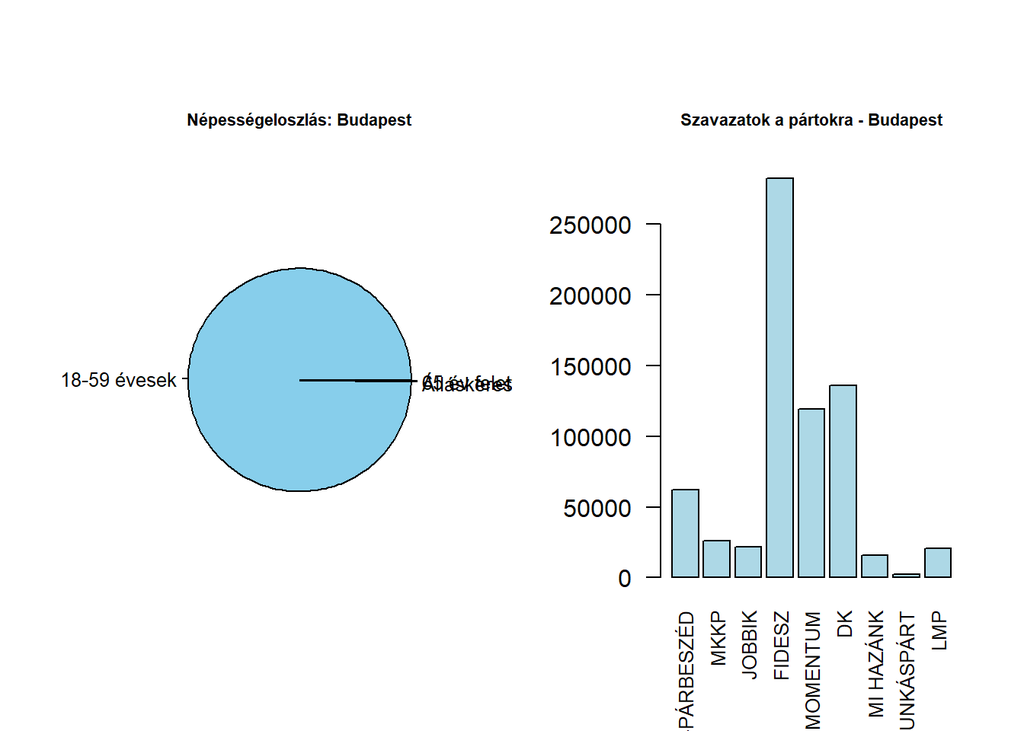

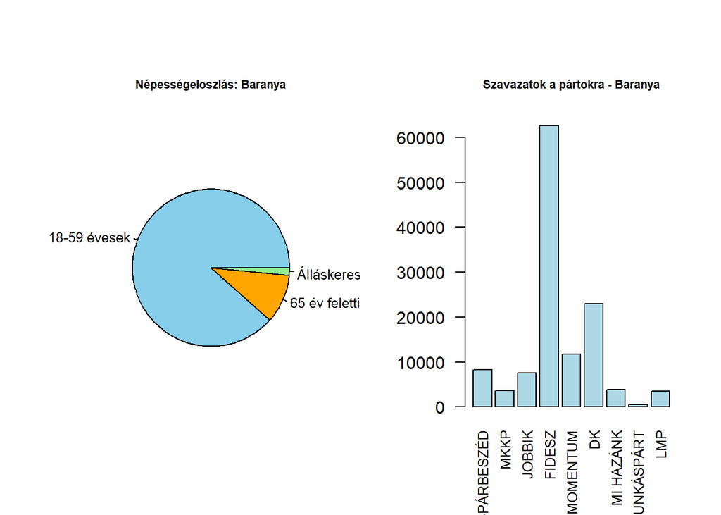

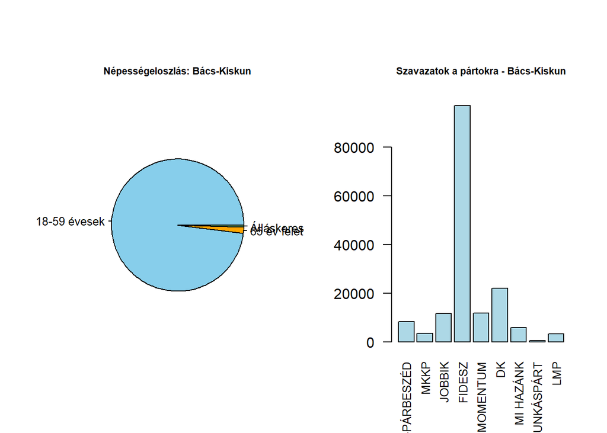

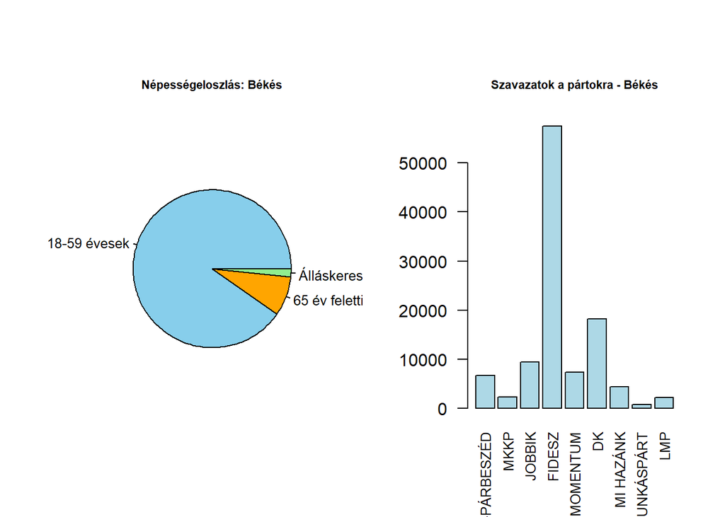

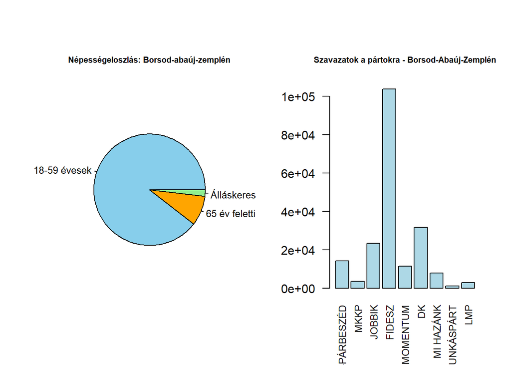

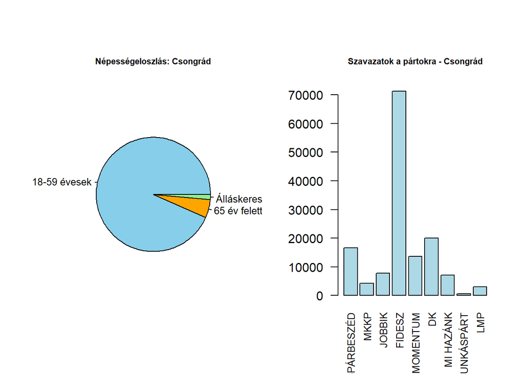

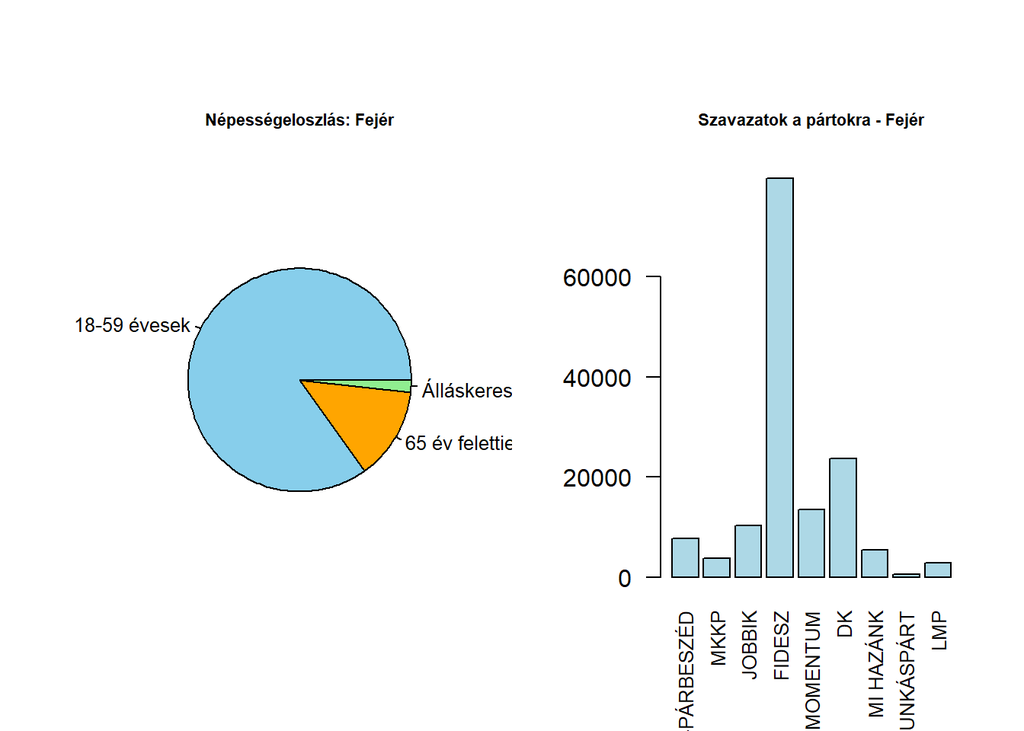

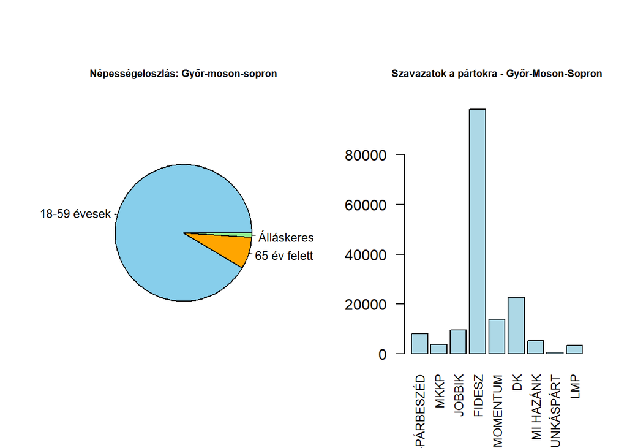

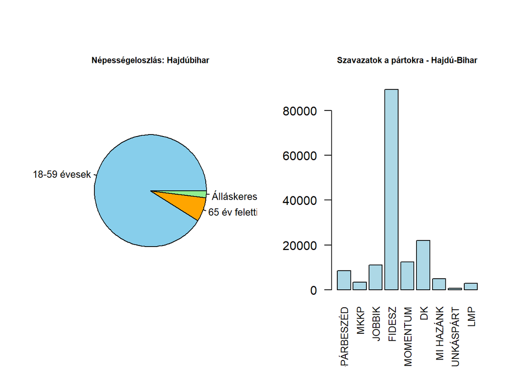

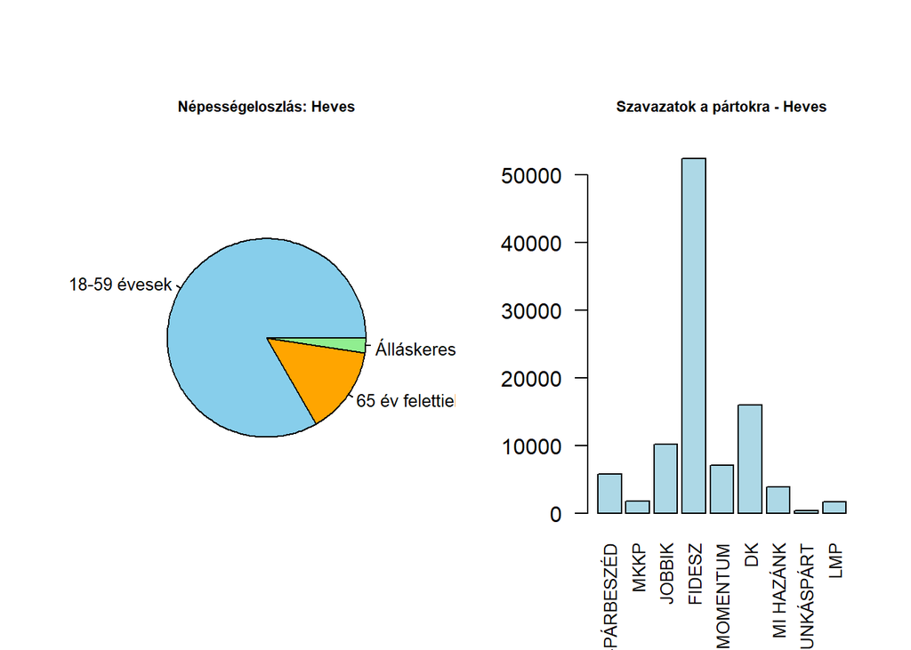

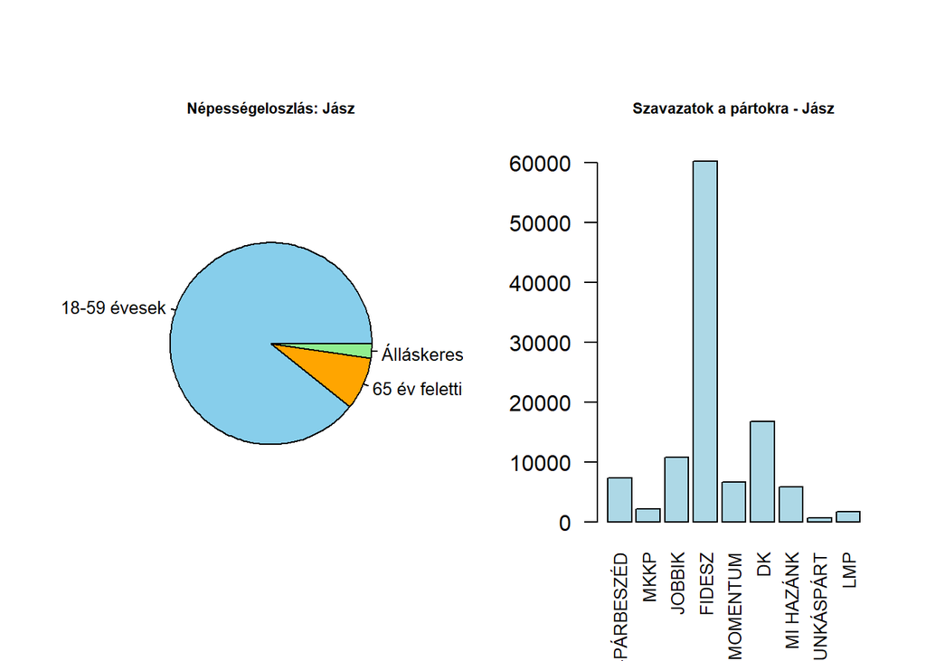

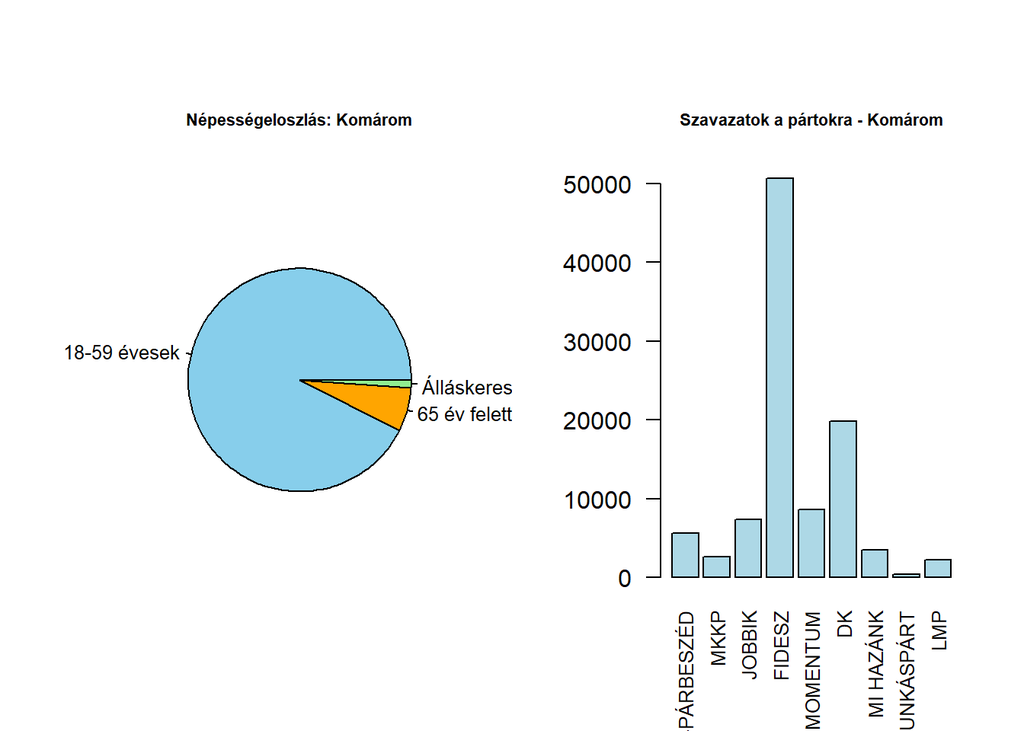

[8 more figures not shown]